# Structural Bayesian Techniques for Experimental and Behavioral Economics

October 16th, 2025. Workshops for Ukraine

## Structural Bayesian Techniques for Experimental and Behavioral Economics

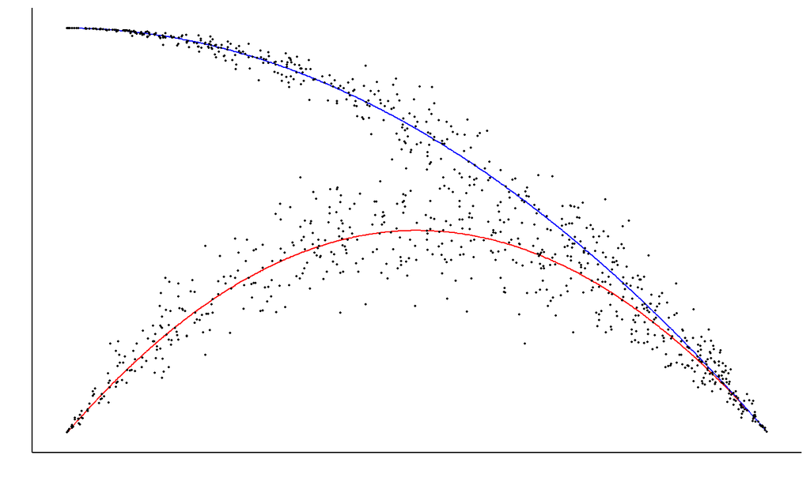

## Introduction

## Answering research questions with structural econometrics

I have a model and data, and I want to …

- **Estimate the parameters** in the model
- Compute **economically meaningfully quantities** from the parameters in my model
- **Quantify how much heterogeneity** is present between participants in my model’s parameters
- Use my model to make a **prediction** about behavior in another setting

But you should also **quantify the uncertainty** you have in all of these

## Estimating parameters in a model

My model says that parameter(s) are important, so I want to know what they are.

For example, some preference models

\[ \begin{aligned} \text{Risk: }& U(L) = E\left(\frac{X^{1-r}}{1-r}\mid L\right) \\ \text{Time: }& U(x) = \sum_{t=0}^{\infty} \delta^t x_t\\ \text{Other-regarding: }& U_i(x)=x_i-\frac{\alpha}{n-1}\sum_{j\neq i}\max\left\{x_j-x_i,0\right\}\\ &\quad\quad \quad\quad-\frac{\beta}{n-1}\sum_{j\neq i}\max\left\{x_i-x_j,0\right\} \end{aligned} \]

## Computing economically meaningful quantities

What I really want to do is interpret a **transformation** of the parameters.

E.g. a certainty equivalent:

\[ \begin{aligned} U(L)&= E\left(\frac{X^{1-r}}{1-r}\mid L\right)\\ \\ & C(L)\sim L\\ C(L)&= \left[E\left(X^{1-r}\mid L\right)\right]^\frac{1}{1-r} \end{aligned} \]

\(C(L)\) converts expected utility units (hard to interpret and compare) into dollars

## Quantifying heterogeneity

Parameter \(\theta\) is likely *not* the same for every participant

Assume (for example):

\[ \theta_i\sim iid N(\mu,\sigma^2) \]

Estimate and interpret \(\mu\) and \(\sigma\)

## Making predictions

Parameters \(\theta\) imply something about choices \(y\) in scenario \(S\):

\[ p(y\mid\theta,S) \]

- For the same participant in another scenario
  - Model evaluation
- For different participants in similar scenarios
  - Scaling an experiment up from a pilot
- For different participants in a new scenario
  - Designing a new experiment

## Structural estimation

Take an **economic model** of how data are generated, and **estimate the parameters** in this model

Then:

- Interpret the estimated parameters
- Derive implications of the estimated parameter values

## Comparison with traditional reduced-form experimental procedures

Theory says that choices \(y\mid D\) will (or will not) be different depending on treatment conditions \(D\).

Design an experiment to test whether or not \(y\mid D_1\) has the same mean, distribution, etc. as \(y\mid D_2\)

Compare treatment outcomes, e.g. with linear regression:

\[ y_{i,t}=\beta_0+\beta_1 D_{i,t}+\epsilon_{i,t},\quad H_0: \ \beta_1=0 \]

## Here’s the differece

**Reduced-form:**

- Model says something about \(y\mid D\)
- Estimate/test for differences between treatments

**Structural:**

- Model **is** a distribution \(y\mid \theta, D\)
- Estimate \(\theta\)

\(\theta\) tells us how treatment conditions \(D\) affect choices \(y\)

We will draw a straight line through the data only if this is what the model says the data will look like!

## The structural approach is *very* different to traditional experimental techniques

Not necessarily a need for:

- Randomization into treatments
- Any (between-subjects) treatments at all
- Designs that could falsify a theory

But you can still use data from a traditionally-designed experiment.

- Structural estimation is a *complement* to the traditional experimental approach
- But: traditional experiment designs may not be optimized for structural estimation

## Structural models for economic experiments

I have a model that describes how participants will make decisions in my experiment.

I will teach you about **probabilistic** models, which specify a probability distribution over decisions in the experiment.

- **Likelihood** \(p(y\mid\theta)\): If you tell me the model’s parameters, I can simulate data for my experiment.
- **Prior** \(p(\theta)\): I have beliefs about what these parameters will look like before running the experiment

Together, I can simulate data for my experiment that is consistent with my prior beliefs about my model’s parameters

\[ p(y)= \int_{\Theta}p(y\mid\theta)p(\theta)\mathrm d\theta = E_\theta\left[p(y\mid\theta)\right] \]

## Applying Bayes’ theorem to learn from data

Bayes’ theorem in general:

\[ \begin{aligned} p(A,B)&=p(A\mid B) p(B)=p(B\mid A)p(A)\\ \text{therefore: }\quad p(A\mid B)&=\frac{p(B\mid A)p(A)}{p(B)} \end{aligned} \]

Bayesian statistics: \(A=\theta\) (parameters), \(B=y\) (data):

\[ \begin{aligned} p(\theta\mid y)&=\frac{p(y\mid\theta) p(\theta)}{p(y)}\propto p(y\mid\theta)p(\theta)=p(y,\theta) \end{aligned} \]

\(p(y\mid\theta)\) is the **likelihood**: given \(\theta\), what will my data look like?

\(p(\theta)\) is the **prior**: what are my beliefs about \(\theta\) before running my experiment?

## Why Bayes?

This is **the right way** to learn from data, according to math!

## Why Bayes? More practically

The alternative is (usually) maximum likelihood.

- Bayes often turns a difficult maximization problem into a slightly less difficult simulation problem.
- The technology to do this simulation has improved *immensely*

Better handling of un-observable heterogeneity

- Data augmentation vs. integrating the likelihood
- Handled particularly well by Hamiltonian Monte Carlo (This is what *Stan* does)
- Participants are heterogeneous!

## Applying Bayes’ rule to structural models in experiments

\[ \begin{aligned} p(\theta\mid y)&=\frac{p(y\mid\theta) p(\theta)}{p(y)}\propto p(y\mid\theta)p(\theta) \end{aligned} \]

A typical procedure:

\(u(y;\theta,x)\): A (deterministic) **utility function** over choices \(y\) given experimental conditions \(x\) and parameters \(\theta\)

\(p(y\mid u,\theta)\): A **stochastic choice rule**

\(p(\theta)\): a prior for our model’s parameters

## Some components of a structural model: Utility function

If present, this is usually the thing we are most interested in

\(u(y;\theta,x)\): A (deterministic) **utility function** over choices \(y\) given experimental conditions \(x\). For example:

Risk preferences: \[ u(y;\theta,x)=\sum_{k=1}^K p^y_k \frac{x_k^{1-r}}{1-r} \]

Time preferences:

\[ u(y;\theta,x)=\sum_{t=0}^\infty \delta^t y_t \]

## The components of a structural model: A probabilistic choice rule

Converts a **deterministic** prediction into a **probabilistic** one.

- Specifies a probability distribution over actions given utility of taking these actions
- Necessary for constructing a likelihood
- Behaviorally plausible

\[ \begin{aligned} \text{logit choice: } p(a\mid x,\theta)&=\frac{\exp(\lambda u_a(x,\theta))}{\sum_{j\in A}\exp(\lambda u_j(x,\theta))}\\ \text{optimal plus error: } y\mid x,\theta&\sim \arg\max_{y'\in A}u(y',x,\theta)+\epsilon,\quad \epsilon\sim N(0,\sigma^2) \end{aligned} \]

## The components of a structural model: A prior

\[p(\theta)\]

Our belief about \(\theta\) before we observe our data

What are:

- Likely values?
- Unlikely but possible values?
- Stupidly unlikely but still possible values?
- Impossible values?
- Values which pose a problem for estimation?

A **formal mathematical statement** of this

## How can we estimate these models?

The posterior distribution \(p(\theta\mid y)\) is in general not known in closed form.

- Fortunately, we can *sample* from it.
- We then report *summary statistics* of these simulated draws (e.g. means, standard deviations).

The more “traditional” Bayesian approach, Gibbs sampling: needs exact conditional distributions for subsets of the parameters.

- Great if you want to only work with linear models (I don’t)
  - Conjugate priors
- Feasible for (mostly non-linear) structural applications, but very slow (see my job market paper (Bland 2019))
- More **user-intensive**

## A better way for estimating structural models

Most of the computationally difficult stuff is in handling the non-linearities, which do not work well with a Gibbs sampler.

Instead, use a *probabilistic programming language* that takes care of all of this!

I will teach you about *Stan* (Carpenter et al. 2017):

- Free, and callable within *R*, *Python*,
- Allows us to code up models in a similar way to how we might write them down
- Uses Hamiltonian Monte Carlo: Fast!
- Especially well suited to handling hierarchical models
- In-built diagnostics

## Example *Stan* program for estimating a Normal distribution

```c
data {
  int<lower=0> N; // number of observations in data
  vector[N] y; // data
  vector[2] prior_mu; // prior for parameter mu (mean and sd)
  real<lower=0> prior_sigma; // prior for sigma (half-cauchy)
}
parameters {
  real mu; // mean of distribution
  real<lower=0> sigma; // standard deviation of distribution
}
model {
  y ~ normal(mu, sigma); // likelihood contribution
  mu ~ normal(prior_mu[1],prior_mu[2]); // prior for mu
  sigma ~ cauchy(0.0,prior_sigma); // prior for sigma
}
```

## What information does *Stan* need? **Overview**

Instructions on how to compute the log joint density of parameters and data:

\[ \log p(y,\theta)=\underbrace{\log p(y\mid\theta)}_\text{likelihood}+\underbrace{\log p(\theta)}_\text{prior} \]

This is called the `target`

## What information does *Stan* need? **Data block**

A description of the data (and any other information you want to pass to *Stan*)

- names
- data types, e.g. `int`, `real`, `vector`, etc.
- array sizes
- bounds (optional)

```c
data {
  int<lower=0> N; // number of observations in data
  vector[N] y; // data
  vector[2] prior_mu; // prior for parameter mu (mean and sd)
  real<lower=0> prior_sigma; // prior for sigma (half-cauchy)
}
```

## What information does *Stan* need? **Parameters block**

- names
- bounds
- parameter types
  - Must be continuous variables
  - `real`, `vector`, `matrix`, `simplex`, `corr_matrix` etc. allowed
  - `int` not allowed

```c
parameters {
  real mu; // mean of distribution
  real<lower=0> sigma; // standard deviation of distribution
}
```

## What information does *Stan* need? **Model block**

Instructions on how to compute the `target`:

\[ \log p(y,\theta)=\log p(y\mid\theta)+\log p(\theta) \]

```c
model {
  y ~ normal(mu, sigma); // likelihood contribution
  mu ~ normal(prior_mu[1],prior_mu[2]); // prior for mu
  sigma ~ cauchy(0.0,prior_sigma); // prior for sigma
}
```

Alternatively:

```c
model {
  target += normal_lpdf(y | mu, sigma); // likelihood contribution
  target += normal_lpdf(mu | prior_mu[1],prior_mu[2]); // prior for mu
  target += cauchy_lpdf(sigma | 0.0,prior_sigma); // prior for sigma
}
```

## Optional *Stan* blocks

`functions`: Specify user-defined functions

`transformed data`: Data manipulations

`transformed parameters`: Calculate functions of parameters and data that can be used in the `model` block (slow-ish)

`generated quantities`: Calculate functions of parameters and data that cannot be used in the `model` block (fast)

## Running *Stan* in *R*

See `exampleStan.R` and `exampleStan.stan`

## Some other things to know about *Stan*

Diagnostics:

- Only about four things that can go wrong with Hamiltonian Monte Carlo
- All of them diagnosable (*Stan* does this for you)
- Extensive documentation on them and how to fix them

Speed:

- Compiles from `C++` \(\implies\) very fast once compiled
- Speed improved through vectorization
- Parallelization supported (both within- and between-chain)

## Will I need a super-fancy computer to do this?

No, but you *will* need a bit of patience

Everything I show you today could be done done on my laptop (bought in 2017) overnight

- Microsoft Surface Pro running Windows 10 Pro
- Processor Intel(R) Core(TM) i7-7660U CPU @ 2.50GHz, 2496 Mhz, 2 Core(s), 4 Logical Processor(s)
- 16 GB RAM (didn’t need anything near this)
- *R* version 4.2.1 (2022-06-23 ucrt)
- *RStan* version 2.26.13 (*Stan* version 2.26.1)

Noticeable slow-down of other processes while running this. That’s why I also have a my office computer

## Outline for the rest of this workshop

1. Models with optimization
   - Estimating a model of other-regarding preferences
2. Hierarchical models
   - Unobservable, participant-specific heterogeneity
3. Doing something with the posterior estimates
   - Generated quantities and out-of-sample predictions
4. Conclusion

## Models with optimization

## What are our participants maximizing?

Economic models usually involve some kind of **optimization**

One way to represent this is with a utility function:

\[ \max_{y\in \mathbb Y} U(y;\theta,x) \]

We can lean about \(\theta\), the parameters in \(U(\cdot;\cdot,\cdot)\), by observing choices \(y\) in different experiment conditions \(x\).

We will often have to make an assumption about the functional form of \(U(\cdot;\cdot,\cdot)\).

## With an estimate of the parameters in \(U\) we can

\[ \max_{y\in \mathbb Y} U(y;\theta,x) \]

- **Interpret** the estimated parameters \(\theta\)
- Calculate **economically meaningful quantities** that are functions of \(\theta\)
- Make (deterministic) **predictions** of what participants might do in different experiment conditions \(x\) and with different choice sets \(\mathbb Y\)

## Example dataset: Bruhin, Fehr, and Schunk (2019)

- 174 participants
- 78 pair-wise choices each
- Allocations of money between self and other participant

## Bruhin, Fehr, and Schunk (2019)

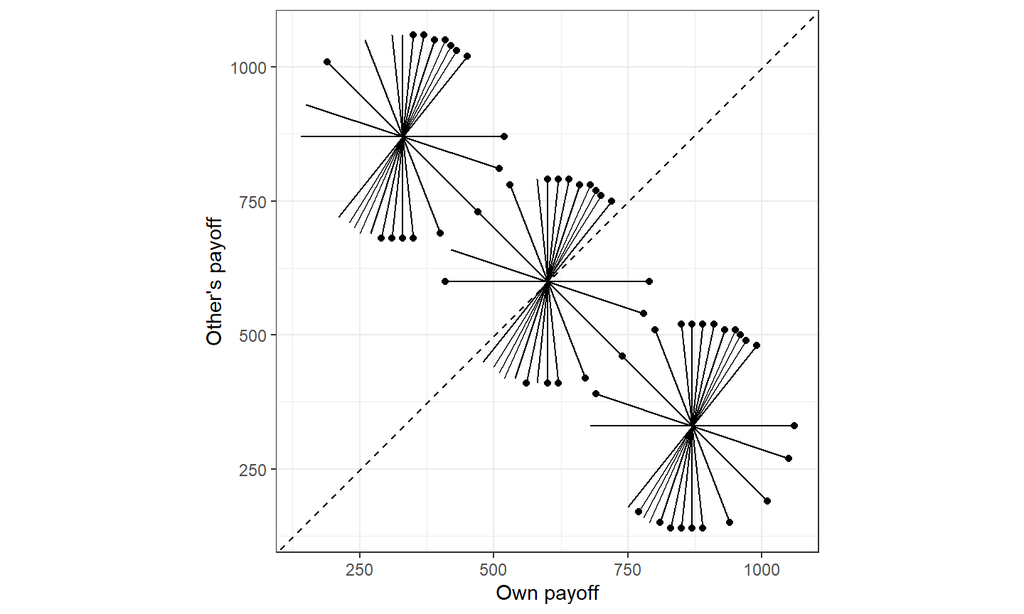

## A model: Fehr and Schmidt (1999)

\[ \begin{aligned} U_i(x,y)&=x-\alpha_i\max\{0,y-x\}-\beta_i\max\{0,x-y\}\\ \text{where: } x&=i\text{'s earnings}\\ y &=\text{the other person's earnings} \end{aligned} \]

Parameters:

- \(\alpha_i\): Aversion to disadvantageous inequality
  - How much I dislike the other person getting more than me
- \(\beta_i\): Aversion to advantageous inequality
  - How much I dislike the other person getting less than me

Fehr and Schmidt (1999) argue that \(\alpha_i\geq \beta_i\) and \(0\leq \beta_i\leq 1\)

## What can we do with this model?

\[ U_i(x,y)=x-\alpha_i\max\{0,y-x\}-\beta_i\max\{0,x-y\} \]

Given parameter values for \(\alpha_i\) and \(\beta_i\), we can:

- Predict which of the two allocations will be chosen

We cannot:

- Simulate data (because the model is deterministic)
- Therefore we can’t estimate our model (yet)

## The problem(s) with deterministic choice

*Economic* models often assume *perfect* optimization (“rationality”), but …

Knowing our participants:

- Real people make mistakes
- Real people don’t have exactly the utility functions we want to assume they have

From a technical perspective:

- Mistakes + deterministic model = zero likelihood!

For a variety of reasons, we need a *probabilistic* model.

## Probabilistic models

Model implies a *probability distribution* over actions in the choice set.

Nice property to have: the probabilistic model looks like noisy optimization

A good place to start: logit choice

\[ \begin{aligned} \Pr(A\mid U_i(A),U_i(B),\lambda)&=\frac{\exp(\lambda U_i(A))}{\exp(\lambda U_i(A))+\exp(\lambda U_i(B))} \end{aligned} \]

- \(\lambda \geq 0\): choice precision
- 50/50 randomization when \(\lambda=0\)
- Approaches noiseless optimization as \(\lambda\to\infty\)
- Options with greater utility are more likely to be chosen than options with less utility

## Logit choice

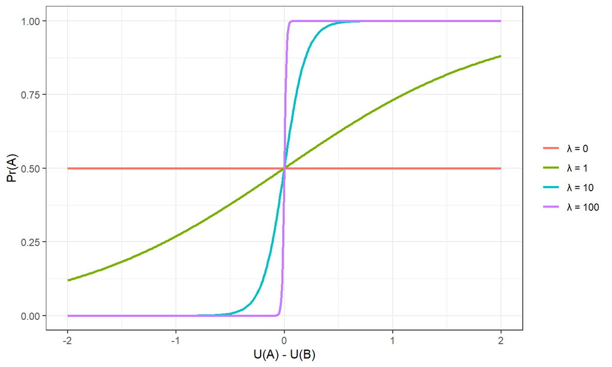

## Up to this point

A (deterministic) model of utility

\[ U_i(x,y)=x-\alpha_i\max\{0,y-x\}-\beta_i\max\{0,x-y\} \]

A probability distribution over actions:

\[ \Pr(A\mid U_i(A),U_i(B),\lambda)=\frac{\exp(\lambda U_i(A))}{\exp(\lambda U_i(A))+\exp(\lambda U_i(B))} \]

At this point we can:

- Simulate data given parameters \((\alpha_i,\beta_i,\lambda_i)\)
  - This is *really useful* when designing an experiment!
- Estimate the model using MLE (if we really want to)

## To do Bayesian inference, we need (good) priors!

## What is a prior?

**Qualitatively:** what we know about our parameter(s) before we see the data

As experts (yes, you are one), you should be able to make a reasonable judgement about what are likely and unlikely realizations of a parameter

- A daily discount factor of \(\delta=0.95\) is ridiculously small (but not for yearly)
- Relative risk-aversion of 0.5 (i.e. square-root utility if CRRA) is not too surprising
- \(\beta=1,000\) in Fehr and Schmidt (1999) is a stupidly large amount of aversion to advantageous inequality.

But we have to **formally state** this in a **mathematical** expression of the uncertainty we have in our parameter(s)

## Step 1: picking a distributional family

Choose a family of distributions that has the right support.

E.g. \(\lambda\geq0\), choice precision:

- Normal – nope: can’t have negative numbers
- Binomial – nope: doesn’t cover \(\mathbb R_+\)
- Log-normal – good

\(\alpha,\beta\in \mathbb{R}\):

- normal

## Step 2: Calibrate the parameters of the distribution

\[ \begin{aligned} \alpha_i&\sim N(m_\alpha,s^2_\alpha)\\ \beta_i&\sim N(m_\beta,s^2_\beta)\\ \log\lambda_i&\sim N(m_\lambda,s^2_\lambda) \end{aligned} \]

Translate our (maybe not very well-formulated) beliefs into \(\{m_\alpha,s_\alpha,\ldots\}\)

This is usually the hard part, think about:

- What parameter values seem Likely? Plausible? Unlikely? Just plain stupid?
- What parameter values make plausible predictions?
- What parameter values might pose problems for estimation?

## For \(\alpha\) and \(\beta\)

\[ \begin{aligned} \alpha&\sim N(0,0.67^2)\\ \beta &\sim N(0,0.67^2) \end{aligned} \]

## For \(\lambda\)

What do different values of \(\lambda\) say about decisions?

To make the math easy, look at the predictions for a selfish (\(\alpha=\beta=0\)) participant:

The unique selfish payoff differences in the experiment are:

```r
d<-(D
    |> mutate(absDiff = abs(self_x-self_y))
    |> dplyr::select(absDiff)
    |> unique()
    )

d |> as.vector() |> print()
```

```
## $absDiff
##  [1] 140 200 380 240 120  80  40 280 180   0 160 360
```

## Selfish behavior and \(\lambda\)

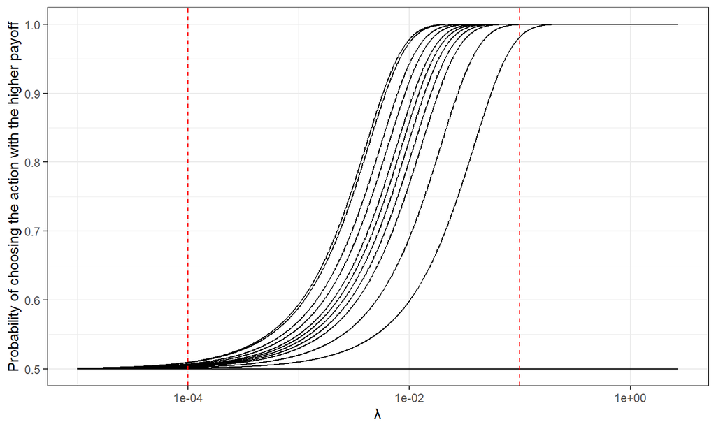

## \(\lambda\) calibration

Set prior 5th percentile to 0.0001, 95th percentile to 0.1

\[ \begin{aligned} \log (0.1)&=m_\lambda+1.64s_\lambda\\ \log(0.0001)&=m_\lambda-1.64s_\lambda\\ \log(0.1)-\log(0.0001)&=2\times1.64s_\lambda\\ s_\lambda&=\frac{\log(0.1)-\log(0.0001)}{2\times 1.64}\approx 2.11\\ m_\lambda &=\log0.1-1.64\times2.11\approx-5.76 \end{aligned} \]

## Now we can estimate the model!

(So let’s look at the code, `RepAgentModels_BFS2019.stan`)

## Model estimates – pooled

Stan summary output

|  | mean | se_mean | sd | percentiles X2.5. | percentiles X25. | percentiles X50. | percentiles X75. | percentiles X97.5. | n_eff | Rhat |
| --- | --- | --- | --- | --- | --- | --- | --- | --- | --- | --- |
| alpha | -0.051 | 0.00 | 0.008 | -0.065 | -0.056 | -0.051 | -0.045 | -0.036 | 4007.291 | 1.000 |
| beta | 0.262 | 0.00 | 0.008 | 0.247 | 0.257 | 0.262 | 0.267 | 0.277 | 3272.100 | 1.002 |
| lambda | 0.016 | 0.00 | 0.000 | 0.015 | 0.015 | 0.016 | 0.016 | 0.016 | 3603.171 | 1.000 |
| lp__ | -4022.763 | 0.03 | 1.236 | -4025.964 | -4023.325 | -4022.435 | -4021.862 | -4021.353 | 1746.229 | 1.001 |

Not particularly interesting – participants aren’t homogeneous

## Model estimates – participant-specific

(showing posterior means only)

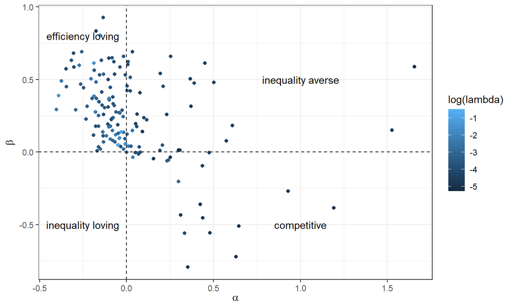

## Hierarchical models

## Taking heterogeneity seriously

- Our participants are likely heterogeneous in many dimensions
  - Observable (i.e. post-experiment survey answers)
  - Unobservable (i.e. different model parameters)

Here we are going to model the **unobservable** heterogeneity

We might be:

- Interested in this heterogeneity
- Worried about heterogeneity (e.g. heterogeneity bias, e.g. Wilcox (2006))
- Seeking better estimates of individual participants’ parameters that leverage the entire dataset

## Treat participants’ parameters as random draws from a population

\[ \theta_i\doteq\begin{pmatrix} \alpha_i\\ \beta_i \\ \log\lambda_i \end{pmatrix}\sim iidN(\mu,\Sigma) \]

Now need to specify “hyper-priors” for:

- \(\mu\): mean of participants’ (transformed) parameters
- \(\Sigma\): variance-covariance matrix

\(\mu\) and \(\Sigma\) become informative priors for \(\theta_i\).

**Joint estimation** of \(\{\mu,\Sigma\}\) and \(\{\theta_i\}_{i=1}^N\)

## Joint estimation?

\[ \theta_i\doteq\begin{pmatrix} \alpha_i\\ \beta_i \\ \log\lambda_i \end{pmatrix}\sim iidN(\mu,\Sigma) \]

Estimate individual-level parameters \(\{\theta_i\}_{i=1}^N\) alongside population-level parameter \(\mu\) and \(\Sigma\)

\[ \begin{aligned} p(\theta,\mu,\Sigma \mid y)&\propto p(y\mid\theta,\mu,\Sigma)p(\theta,\mu,\Sigma)\\ &=\underbrace{p(y\mid \theta)}_{\text{likelihood}}\overbrace{p(\theta\mid \mu,\Sigma)}^\text{prior}\underbrace{p(\mu,\Sigma)}_\text{hyper-prior} \end{aligned} \]

**Likelihood:** Same as individual-level estimation!

## Hyper-priors

Decompose \(\Sigma\) into a vector of standard deviations \(\tau\) and a correlation matrix \(\Omega\)

\[ \begin{aligned} \mu_\alpha&\sim N(0,0.39^2),&\quad \tau_\alpha\sim \mathrm{Cauchy}^+(0,0.79)\\ \mu_\beta&\sim N(0,0.39^2),&\quad \tau_\beta\sim \mathrm{Cauchy}^+(0,0.79)\\ \mu_\lambda&\sim N(-5.76,1^2),&\quad \tau_\lambda\sim\mathrm{Cauchy}^+(0,0.24)\\ \Omega&\sim \mathrm{LKJ}(2) \end{aligned} \]

Similar reasoning to individual participant model.

## Estimating the model in *Stan*

(see `Hierarchical_BFS2019_correlated.stan`)

Things to note:

- Likelihood calculation is exactly the same as in individual-level estimation
- Joint estimation of individual-level parameters

Here I follow the recommendations of https://mc-stan.org/docs/stan-users-guide/regression.html#multivariate-hierarchical-priors.section

- Decomposition of \(\Sigma\) into standard deviations \(\tau\) and correlation matrix \(\Omega\)
- Cholesky factorization of \(\Omega\)
- Non-central parameterization of individual-level parameters

## Things we can do with a hierarchical model

1. Comment on the estimates of **central tendency** \(\mu\) (“representative agent”)
2. Comment on estimates of **spread** \(\Sigma\)
3. Estimate individual-level parameters with a prior **informed by the entire dataset**
   - Anything we can do with individual-level estimates we can also do with a hierarchical model!

## Population-level estimates

| parameter | mean | se_mean | sd | X2.5. | X25. | X50. | X75. | X97.5. | n_eff | Rhat |
| --- | --- | --- | --- | --- | --- | --- | --- | --- | --- | --- |
| \(\mu_\alpha\) | -0.014 | 0.001 | 0.015 | -0.044 | -0.024 | -0.014 | -0.004 | 0.017 | 898.269 | 1.008 |
| \(\mu_\beta\) | 0.230 | 0.001 | 0.020 | 0.191 | 0.216 | 0.230 | 0.243 | 0.269 | 1156.227 | 1.004 |
| \(\mu_\lambda\) | -3.531 | 0.002 | 0.068 | -3.662 | -3.576 | -3.532 | -3.486 | -3.394 | 1593.340 | 1.004 |
| \(\tau_\alpha\) | 0.175 | 0.000 | 0.014 | 0.149 | 0.165 | 0.174 | 0.184 | 0.204 | 1584.464 | 1.001 |
| \(\tau_\beta\) | 0.242 | 0.000 | 0.016 | 0.211 | 0.231 | 0.241 | 0.252 | 0.275 | 1692.600 | 1.000 |
| \(\tau_\lambda\) | 0.774 | 0.002 | 0.062 | 0.660 | 0.731 | 0.771 | 0.814 | 0.902 | 1292.542 | 1.001 |

## Individual-level estimates

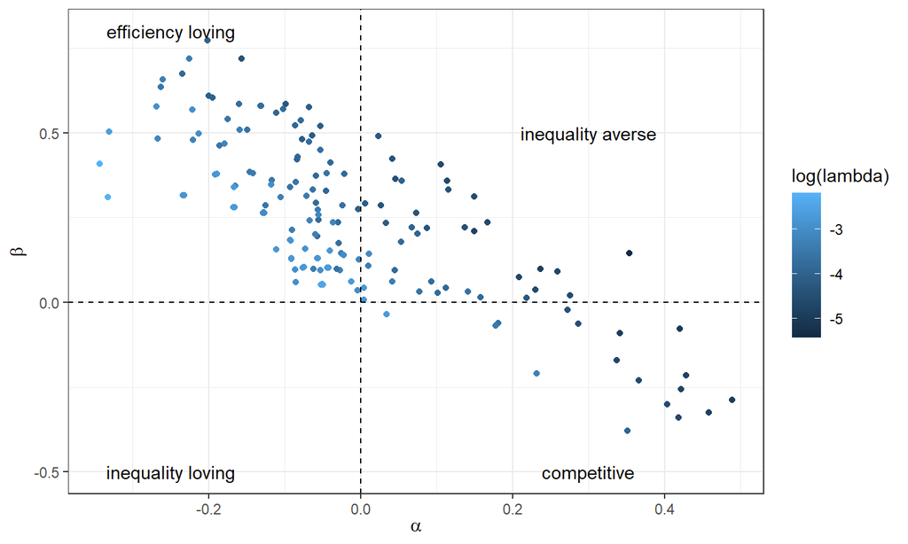

## Comparing the hierarchical and individual models

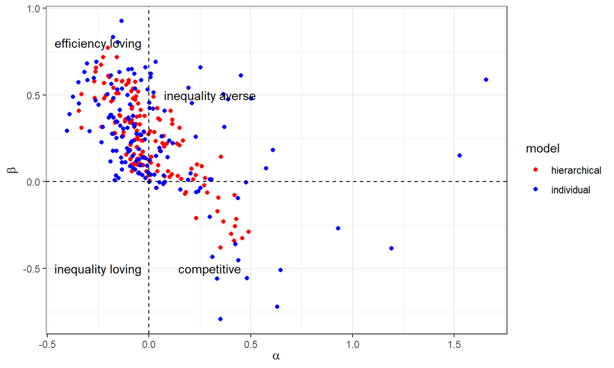

## Up to this point

We can estimate the parameters of our model.

**However:** Sometimes the raw parameters are less interesting than *functions* of the parameters:

We might be interested in:

- Predictions
  - Out-of-sample
  - Designing a new treatment or experiment
- Welfare measures
- Classifying participants into groups

## Beyond estimation: `generated quantities`

## Sometimes we are interested in *transformations* of our parameters

- We estimate a CRRA utility function, but we are really interested in a risk premium
- We estimate a quantal response equilibrium, but we are really interested in its prediction for another game
- We estimate the fraction of participants who bracket decisions narrowly, but we are really interested in how much utility they are giving up (my JMP).

We are often **more** interested in these transforms than the parameters themselves

## The good news (and there’s no bad news)

**We get transformations of parameters for free!**

Once we have our posterior simulation, to get a simulation of transformations of parameters, we just transform the simulated parameters.

E.g. If \(\{\theta_s\}_{s=1}^S\) are our simulated parameters, and \(g(\theta)\) is the transformation we are interested in, then:

\[ E[g(\theta)\mid y]\approx \frac{1}{S}\sum_{s=1}^Sg(\theta_s) \]

(the approximation is up to simulation accuracy)

**Even better:** we can do this in *Stan*, so it all happens very fast!

## Application: predicting behavior in another environment

**A new task:**

You have 1000 tokens. You will earn 1 experimental currency unit per token that you choose to keep. You can also buy income for another participant (who has no tokens) at a price of \(\rho\) tokens per experimental currency unit. That is, if you spend 100 tokens on the other participant, they earn \(\frac{100}{\rho}\) experimental currency units.

**Research question:** What is the population demand for giving to the other participant?

## We already have a model for this

**What is the population demand for giving to the other participant?**

\[ \begin{aligned} U_i(x,y)&=x-\alpha\max\{0,y-x\}-\beta_i\max\{0,x-y\}\\ \text{Budget constraint: }1000&=x+\rho y \end{aligned} \]

and logit choice over the budget set (discretized to units of 1 token)

## Solving the model …

Substituting in the budget constraint gets us:

\[ \begin{aligned} U_i(x)&=x-\alpha_i\max\left\{0,\frac{1000-x(1+\rho)}{\rho}\right\}-\beta_i\max\left\{0,\frac{x(1+\rho)-1000}{\rho}\right\} \end{aligned} \]

Then logit choice gives us:

\[ \Pr(X=x\mid \alpha_i,\beta_i,\lambda_i,\rho)=\frac{\exp(\lambda_iU_i(x))}{\sum_{k=0}^{1000}\exp(\lambda_iU_i(k))} \]

and the expected amount kept is:

\[ E[X\mid \alpha_i,\beta_i,\lambda_i,\rho]=\sum_{x=0}^{1000}x\frac{\exp(\lambda_iU_i(x))}{\sum_{k=0}^{1000}\exp(\lambda_iU_i(k))} \]

## … more working …

But what we really want is \(Y\), so using the budget constraint:

\[ E[Y\mid \alpha_i,\beta_i,\lambda_i,\rho]=\frac{1000-E[X\mid \alpha_i,\beta_i,\lambda_i,\rho]}{\rho} \] This is the expected quantity demanded given parameters \(\{\alpha_i,\beta_i,\lambda_i\}\).

From here, we want to take a population-average over these parameters, so applying the law of iterated expectations:

\[ E[Y\mid \rho]=E\left[E[Y\mid \alpha_i,\beta_i,\lambda_i,\rho]\mid \rho\right] \]

This is a function of the population-level parameters \(\mu\) and \(\Sigma\). It is hard to evaluate analytically, but we can approximate it numerically …

## … more working

\[ \begin{aligned} E[Y\mid \rho]=E\left[E[Y\mid \alpha_i,\beta_i,\lambda_i,\rho]\mid \rho\right]&\approx \frac1S\sum_{s=1}^SE[Y\mid \tilde\alpha_s,\tilde\beta_s,\tilde\lambda_s,\rho]\\ \text{where: } \begin{pmatrix} \tilde\alpha_s\\ \tilde\beta_s \\\log \tilde\lambda_s \end{pmatrix}&\sim iid N(\mu,\Sigma) \end{aligned} \]

(go back to *Stan* model `Hierarchical_BFS2019_correlated.stan`)

## Results

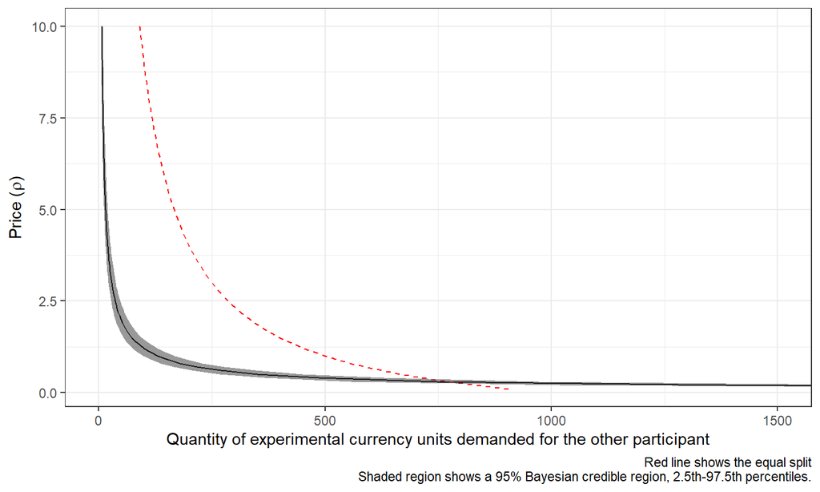

## Conclusion

## Big picture

I have a model and I want to:

- Estimate and comment on the parameters
- Estimate and comment on *transformations* of the parameters
- Assign a measure of uncertainty to all of the above

We have a framework for doing this

## Bayesian statistics

Applying Bayes’ rule to quantify posterior uncertainty in:

- Our model’s parameters

\[ p(\theta\mid y)\propto p(y\mid \theta) p(\theta) \]

- Assigning probabilities to models

\[ p(M\mid y)\propto p(y\mid M) p(M) \]

## The structural approach

**Estimate the parameters in the model**

- Interpret the parameters
- Interpret implications of the parameters, e.g.:
  - Predicted actions
  - Certainty equivalents

Compared to reduced-form:

- Compare differences in treatments,
- Draw a straight line through the data, interpret the slope

## Heterogeneity

Our participants are heterogeneous, and we should model this!

Bayesian techniques do this well

Some useful tools:

- Hierarchical models: Continuous types
  - Data augmentation
- Mixture models: Discrete types
  - Integrate the likelihood

Heterogeneity in a parameter could be important, even if you don’t care about that parameter!

## So when should I think about structural?

**Before running an experiment!**

- What parameters/quantities do I want to estimate?
- What might my data look like?
- Can I modify my experiment to better answer my research question?
- Will my experiment adequately estimate the models/quantities that I want it to?
- What kind of data (e.g. discrete or continuous) will make my estimation problem easier?

**After the experiment**

- To complement a traditional analysis (comparing treatments)
- Estimate economically meaningful quantities

## What are some things I should be thinking about when estimating structural models?

- How will this help **answer my research question**?
  - Economically meaningful quantities
  - Parameters/quantities that we can interpret
- What are the **underlying assumptions** of the model(s) I take to the data?
- Can I relax these assumptions?
  - More flexible functional forms
  - More parametric models (in mixture or separately)
- How am I accounting for **heterogeneity**?
  - Heterogeneity that I care about
  - Heterogeneity that I don’t care about but might affect my estimates

## What are some things to think about when doing **Bayesian** work?

- What do my priors say about:
  - Reasonable and unreasonable parameter values?
  - The data I might collect?
  - Economically meaningful quantities
  - The performance of my estimator?
- Data augmentation
  - Good for models with heterogeneity
  - In *Stan*: only continuous variables – integrate the likelihood for discrete heterogeneity

## What are some things to think about when implementing a model in *Stan*?

Re-parameterizations

Efficient coding

- Know your bottlenecks!
- Pre-computing things
- Vectorized operations (avoiding `for` loops)

Parallelization: Between- and within-chain

## What should I think about when communicating my results?

Pictures really help

Try to communicate both:

- The point estimate (e.g. posterior mean), and
- An expression of uncertainty (e.g. posterior standard deviation, 95% Bayesian credible region)

Beware of over-plotting when it comes to individual-level parameters

Make tables that look comforting to reduced-form frequentists:

- regression-like tables
- Posterior mean with standard deviation in parentheses

## Placating the frequentists

Stress the **practical** side of Bayesian estimation: it can turn a difficult maximization problem into a slightly less difficult simulation problem

- Especially for hierarchical models
- Expressions of uncertainty
  - Bayesian – part of the simulation
  - Frequentist – bootstrap or delta method
- **Show them what you can do with Bayes**

Show that you have thought about your priors.

- Have a good answer for why you chose them.
- Maybe do a prior sensitivity analysis

## Things not covered today but worth a look

Experiment design

- With the goal of estimating a structural model
- Using structural estimates
- E.g. Bland (2023)

Model selection using cross-validation

- Not specific to Bayes
- Application to QRE here: Bland (2022)

Finite mixture models: more than one data-generating process

Within-chain parallelization in *Stan* (only if you have idle cores)

## Where are some datasets I can use to practice?

Experimental economics has really good data-sharing norms! If a paper is published, chances are you can get the data.

- Journal websites
- Authors’ websites, e.g:
  - Glenn Harrison: https://cear.gsu.edu/gwh/
  - Guillaume Frechette: http://people.cess.fas.nyu.edu/frechette/html/papers.htm
  - Peter Moffatt (Experimetrics online resources): https://www.bloomsburyonlineresources.com/experimetrics-econometrics
- Email people!

`james.bland@utoledo.edu`

## Thank you!

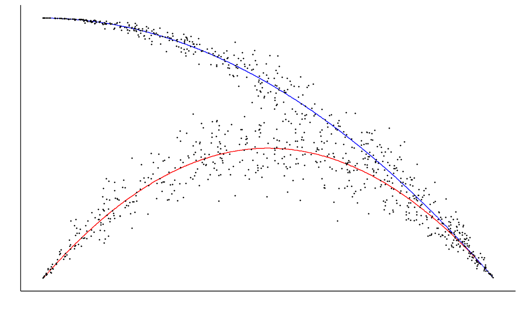

## References

Bland, James R. 2019. “How Many Games Are We Playing? An Experimental Analysis of Choice Bracketing in Games.” *Journal of Behavioral and Experimental Economics* 80: 80–91. https://doi.org/10.1016/j.socec.2019.03.011.

———. 2022. “Bayesian Inference for Quantal Response Equilibrium in Normal-Form Games.” *Available at SSRN 3748586*. https://papers.ssrn.com/sol3/papers.cfm?abstract_id=3748586.

———. 2023. “Optimizing Experiment Design for Estimating Parametric Models in Economic Experiments.” *Available at SSRN 4566855*.

Bruhin, Adrian, Ernst Fehr, and Daniel Schunk. 2019. “The Many Faces of Human Sociality: Uncovering the Distribution and Stability of Social Preferences.” *Journal of the European Economic Association* 17 (4): 1025–69.

Carpenter, Bob, Andrew Gelman, Matthew D Hoffman, Daniel Lee, Ben Goodrich, Michael Betancourt, Marcus A Brubaker, Jiqiang Guo, Peter Li, and Allen Riddell. 2017. “Stan: A Probabilistic Programming Language.” *Journal of Statistical Software* 76.

Fehr, Ernst, and Klaus M Schmidt. 1999. “A Theory of Fairness, Competition, and Cooperation.” *The Quarterly Journal of Economics* 114 (3): 817–68.

Wilcox, Nathaniel T. 2006. “Theories of Learning in Games and Heterogeneity Bias.” *Econometrica* 74 (5): 1271–92.